# Jupyter / IPython sihirli ifadeler

## %pastebin: Kod parçası paylaşmak

`%pastebin` sihri, bir dosyayı, veya mevcut oturumdan seçtiğiniz satırları [dpaste.com](https://dpaste.com/) sitesinde herkese açık olarak yayınlar ve URL’sini döndürür.

```python
%pastebin -d "Deneme yüklemesi" 1-11
```

```
'https://dpaste.com/D73XU7CMS'
```

```python
%pastebin -d "Deneme yüklemesi" merhaba.py
```

```
'https://dpaste.com/GDS5QF5WM'
```

## %who: Oturumda tanımlanmış değişkenler

Mevcut oturumda tanımlanmış değişken isimlerini gösterir.

```python
%who
```

```
isim
```

Değişken isimlerini bir liste olarak almak isterseniz `%who_ls` kullanabilirsiniz.

```python
%who_ls
```

```
['isim']
```

## %reset: Değişkenleri topluca silmek

Mevcut oturumda kullanıcı tarafından tanımlanmış değişkenleri siler. Modüllerde tanımlanmış isimlere dokunmaz.

```python
x = 1
s = "asdfg"
```

```python
%who
```

```
isim     s   x
```

```python
%reset
```

```
Nothing done.
```

```python
%who
```

[output not shown]

Parametreler: * `%reset -f :` Teyit istemeden sıfırlar. * `%reset -s :` Yumuşak sıfırlama: Komut geçmişi silinmez, sadece isim alanı temizlenir. * `%reset in :` Komut geçmişini sıfırlar. * `%reset out :` Çıktı geçmişini sıfırlar. * `%reset dhist :` Dizin geçmişini sıfırlar. * `%reset array :` Sadece NumPy dizi (array) değişkenlerini siler.

## %macro: İşlemleri otomatik olarak tekrar etmek

Arka arkaya yazdığınız birkaç komutu daha sonra tekrar tekrar işletmek için bir kenara yazmak istediğinizde `%macro` sihri işinize yarayacaktır. Bu işlem,de daha önce verdiğimiz komutları giriş sayılarını vererek bir seferde çalıştırabiliriz.

```python
from random import randint
```

```python
zar1 = randint(1,6)
```

```python
zar2 = randint(1,6)
```

```python
zar3 = randint(1,6)
```

```python
a = 5
```

```python
print(zar1 + zar2)
```

```
8
```

```python
print(zar1, zar2, zar3, zar1+zar2+zar3)
```

```
5 3 3 11
```

Bu komutları kullanarak bir makro hazırlayalım. Girdi numaralarını hücrelerin yanından okuyabileceğimiz gibi, `%hist -n` sihiriyle de görebiliriz.

```python
%hist -n
```

… 40: from random import randint 41: zar1 = randint(1,6) 42: zar2 = randint(1,6) 43: zar3 = randint(1,6) 44: a = 5 45: print(zar1 + zar2) 46: print(zar1, zar2, zar3, zar1+zar2+zar3) 47: %hist -n

`%macro` sihirli kelimesinden sonra, makroya vereceğiniz isim ve komut numarası aralıkları gelmelidir. Aralıklar `n1-n2 n3-n4 n5` şeklinde verilebilir. Aralıkların başı ve sonu dahil edilir. Araya virgül koyulmaz.

```python
%macro zar_at 40-43 46
```

```
Macro `zar_at` created. To execute, type its name (without quotes).
=== Macro contents: ===
from random import randint
zar1 = randint(1,6)
zar2 = randint(1,6)
zar3 = randint(1,6)
print(zar1, zar2, zar3, zar1+zar2+zar3)
```

```python
zar_at
```

```
4 6 4 14
```

## %save: Komutları kaydet

Hazırladığınız bir makroyu veya girdi satırlarının bir kısmını sonraki bir oturumda kullanmak için sabit diske yazmak isterseniz `%save` sihrini kullanabilirsiniz. Parametre olarak satır numaraları aralıkları veya numara listesi verilebilir.

```python
%save deneme 40-43 46
```

```
The following commands were written to file `deneme.py`:
from random import randint
zar1 = randint(1,6)
zar2 = randint(1,6)
zar3 = randint(1,6)
print(zar1, zar2, zar3, zar1+zar2+zar3)
```

Satır numaraları yerine daha önce hazırladığınız bir makronun ismini de verebilirsiniz.

```python
%save deneme zar_at
```

```
The following commands were written to file `deneme.py`:
from random import randint
zar1 = randint(1,6)
zar2 = randint(1,6)
zar3 = randint(1,6)
print(zar1, zar2, zar3, zar1+zar2+zar3)
```

## %store: Değişkenleri sabit diske kaydet

Hesabınız sırasında ürettiğiniz bazı değişkenleri sonraki oturumlarda kullanmak için kaydetmek istediğinizde bu sihri kullanabilirsiniz.

```python
L = [i*2 for i in range(10)]
```

```python
%store L
```

```
Stored 'L' (list)
```

Değişkenleri silelim:

```python
%reset -f
```

Artık *L* listesini kaybettik.

```python
print(L)
```

```
NameError: name 'L' is not defined
```

*L* değişkenini kaydedilen yerden geri yükleyelim.

```python
%store -r L
```

```python
print(L)
```

```
[0, 2, 4, 6, 8, 10, 12, 14, 16, 18]
```

```python
%store L >kareler.txt
```

```
Writing 'L' (list) to file 'kareler.txt'.
```

```python
%cat kareler.txt
```

```
[0, 2, 4, 6, 8, 10, 12, 14, 16, 18]
```

```python
!rm kareler.txt
```

## matplotlib arayüzünü ayarlamak

*matplotlib* Python’un gayrıresmi görselleştirme kütüphanesidir. Özel `%matplotlib` sihriyle, hangi arka yüzü kullanmak istediğinizi belirleyebilirsiniz.

```python
%matplotlib -l
```

```
Available matplotlib backends: ['tk', 'gtk', 'gtk3', 'gtk4', 'wx', 'qt4', 'qt5', 'qt6', 'qt', 'osx', 'nbagg', 'webagg', 'notebook', 'agg', 'svg', 'pdf', 'ps', 'inline', 'ipympl', 'widget']
```

Bu arka yüzlerin hepsi her işletim sisteminde bulunmayabilir.

Birçok Jupyter defter kullanıcısı, defterin başında `%matplotlib inline` komutunu vermeyi tercih eder. Bu sayede ürettiğiniz matplotlib grafikleri defterin içine gömülür ve tam bir belge oluşturmanızı sağlar.

```python
%matplotlib inline
```

```python
import matplotlib.pylab as plt
x = plt.linspace(-20,20,100)
y = plt.sin(x)/x
plt.plot(x,y)
```

[output not shown]

Bunun yerine `notebook` arka yüzü kullanmayı tercih ederseniz, fareyle etkileşebileceğiniz, kaydırıp zumlayabileceğiniz dinamik bir formda gösterilir.

*Dikkat*: matplotlib arka yüzünü bir oturum içinde sadece bir kere belirleyebilirsiniz. Aşağıdaki komutlar için çekirdeği tekrar başlatmanız gerekecektir. Çekirdeği, menü çubuğunda *Kernel -> Kernel Restart* seçerek, veya iki kere sıfıra basarak tekrar başlatabilirsiniz.

```python
%matplotlib notebook
```

```python
import matplotlib.pylab as plt
x = plt.linspace(-20,20,100)
y = plt.sin(x)/x
plt.plot(x,y)
```

Deftere gömülü olarak bir etkileşimli grafik arayüzü elde ederiz.

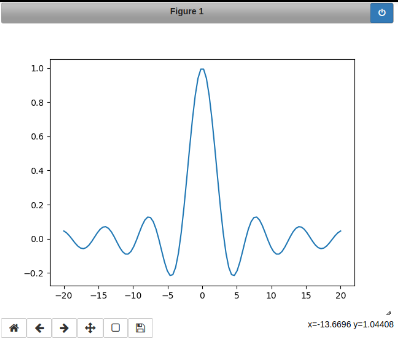

Grafiğin ayrı bir pencerede gösterilmesini istiyorsanız `gtk`, `qt`, `agg`, ve türevlerini kullanabilirsiniz. O zaman en sonda matplotlib’in `show()` komutunu vermelisiniz.

```python
%matplotlib qt5
```

```python
import matplotlib.pylab as plt
x = plt.linspace(-20,20,100)
y = plt.sin(x)/x
plt.plot(x,y)
plt.show()
```

Bu komutlardan sonra grafik şöyle bir pencerede gösterilir.

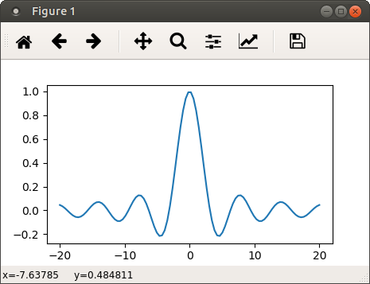

## %%script: Herhangi bir yorumlayıcıyı çalıştır

Başka dillere ait yorumlayıcıları kullanmaya ne dersiniz? Belki bir sürü veri dosyasını hızlıca işlemek için birkaç kabuk komutu vereceksiniz. Belki *Awk*, *Perl*, ya da *Ruby* ile hızlı bir işlem yapmak istiyorsunuz. Sisteminize kurulu herhangi bir yorumlayıcıyı çalıştırıp ona komutlar vermek için `%%script` hücre sihrini kullanabilirsiniz.

Hücrenin başına `%%script`’in ardından yorumlayıcı programın adını, ve gerekiyorsa bazı parametreleri yazın. Hücredeki alt satırlar yorumlayıcıya gönderilip işlenecek, gelen cevap ekrana basılacak.

```python
%%script bash
for i in 1 2 3; do
echo $i
done
```

```
1
2
3
```

## %%html: HTML yorumlayıcı

Bulunduğu hücredeki HTML kodunu işler ve HTML belgesini ekrana verir.

```python
%%html
<html>
<head>
<style>
table {
    font-family: arial, sans-serif;
    border-collapse: collapse;
    widtd: 100%;
}

th, td {
    border: 1px solid #dddddd;
    text-align: left;
    padding: 8px;
}

tr:nth-child(even) {
    background-color: #dddddd;
}
</style>
</head>
<body>
<h1> Çevrimiçi alışveriş veri kayıtları </h1>
<table class="table table-bordered table-hover table-condensed">
<thead><tr><th title="Field #1">InvoiceNo</th>
<th title="Field #2">StockCode</th>
<th title="Field #3">Description</th>
<th title="Field #4">Quantity</th>
<th title="Field #6">UnitPrice</th>
</tr></thead>
<tbody><tr>
<td align="right">536365</td>
<td>85123A</td>
<td>WHITE HANGING HEART T-LIGHT HOLDER</td>
<td align="right">6</td>
<td align="right">2.55</td>
</tr>
<tr>
<td align="right">536365</td>
<td>71053</td>
<td>WHITE METAL LANTERN</td>
<td align="right">6</td>
<td align="right">3.39</td>
</tr>
<tr>
<td align="right">536365</td>
<td>84406B</td>
<td>CREAM CUPID HEARTS COAT HANGER</td>
<td align="right">8</td>
<td align="right">2.75</td>
</tr>
</tbody></table>

</body>
</html>
```

Çevrimiçi alışveriş veri kayıtları

| InvoiceNo | StockCode | Description | Quantity | UnitPrice |
| --- | --- | --- | --- | --- |
| 536365 | 85123A | WHITE HANGING HEART T-LIGHT HOLDER | 6 | 2.55 |
| 536365 | 71053 | WHITE METAL LANTERN | 6 | 3.39 |
| 536365 | 84406B | CREAM CUPID HEARTS COAT HANGER | 8 | 2.75 |